[Home](https://canholyavkin.github.io) - [Other Posts](https://canholyavkin.github.io/#blog) - Contact

# Genomik ve Blockchain

Son bir yıldır **blockchain** ve kaçınılmaz olarak **bitcoin** kelimelerini sıkça duymaya başladık. Binlerce start-up firma, blockchain teknolojisini kullanarak farklı alanlarda ürünler üretmeye başladı. Havacılıktan bankacılık sektörlerine kadar birçok alan, bu yeni ve “havalı” teknolojiye ayak uydurmaya başladı. **Peki, genetik alanında bu teknolojinin kullanımı var mı? Hangi firmalar bu teknolojiyi kullanıyor ve neler vadediyorlar?** Bu yazıda, blockchain’in genomik alanındaki izlerine değiniyoruz.

# Blockchain Nedir ve Neden Güvenilir?

Yazıya hızlı bir giriş yapabilmek amacıyla, Blockchain’i olabildiğince basit anlatmaya çalışacağım.

200.000 kişi ile ortak çalıştığınız bir Word dokümanı hayal edin. Bu dokümana eklediğiniz tüm yeni kayıtların diğer tüm kullanıcıların word dokümanında da oluştuğunu düşünebilirsiniz. Şimdi yeni bir satır ekleyin. Bu satırda, “*X numaralı hesaba Y adet bitcoin gönderdim.*” yazmış olsun. Siz bu kaydı girdiğinizde, blockchain sisteminde, **sizinle beraber aynı dokümanı paylaşan 200.000 kullanıcıya bu istek gider. Her kullanıcı bu değişikliği onaylar.** Herkesten onay alındığında geri dönüşü olmayacak şekilde ilgili kayıt o dokümana eklenmiş olur.

Sistemi kandırmak için aynı anda birbirini tanımayan 200.000 kişinin de hatalı bir şekilde onay vermesi gerekir. **Bu durum pratikte mümkün olmadığı için blockchain üzerinde kayıtlı veriler oldukça güvenilir sayılabilir.**

Sistemin güvenilir olmasını sağlayan esas faktörler ise, kayıtlı her bilginin bloklar içinde tutulmasından kaynaklanıyor. Her bir blok bir **hash kodu** ile adlandırılıyor. **Blok içinde tutulan herhangi bir veri değiştiğinde otomatik olarak bu hash kodu da değişiyor** ve önceki hash kodu geçersiz oluyor.

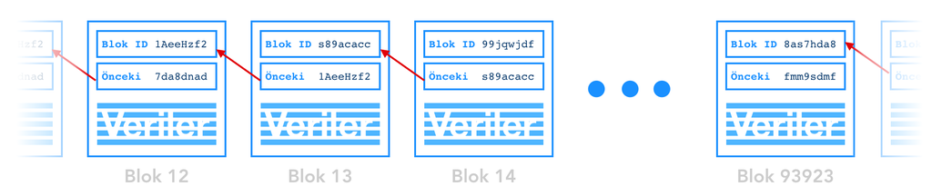

Her bir blok, kendinden önce kaydedilen bloğun hash kodunu (bir nevi adını) da kaydediyor. **Bu şekilde veriler, bir blok zinciri (block-chain) halinde kaydediliyor.** Eğer blokların birinin içindeki bilgi değişirse, adı (hash kodu) değişiyor. Bu durumda, sonraki blok ile uyumsuz hale geliyor.

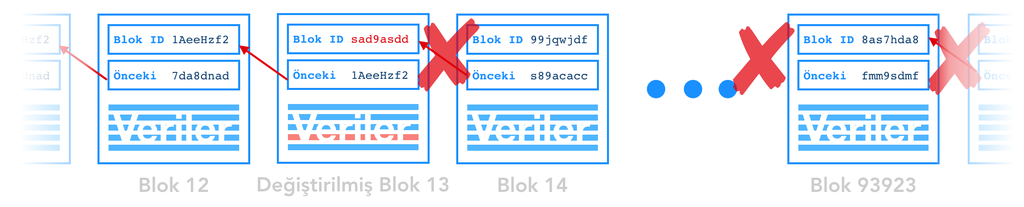

Bu yolla, bir kere zincir içine kaydedilen veriler, artık silinemiyor veya değiştirilemiyor. Sistemin güvenilirliği sağlanmış oluyor.

Teknolojiden bahsettik. Peki kaydedilen veriler? Girilen bu kayıtlar elbette sadece para göndermekten ibaret değil. Aklınıza gelebilecek her türlü log kaydını blockchain kullanarak kayıt altına alabiliyorsunuz. Örneğin *“A3134X no’lu genom verisi Drug-O-Rama Inc. tarafından kullanıldı.”* gibi.

# Yeni Nesil Genetik Start-up Firmaları

BigBang olmuşçasına birden bire peydahlanan yüzlerce firmayı gördükçe, ister istemez genetik alanının bu teknolojiden nasıl faydalanabileceğini düşünüyorsunuz. Ben tam bu düşüncelere sahipken, yanlız olmadığımı e-posta adresime gelen bir [whitepaper](http://variantgenetik.com/wp-content/uploads/2018/02/Shivom-Executive-Summary.pdf) ile farkettim.

Whitepaper, [Shivom](https://shivom.io/) adlı Hindistan kökenli bir firmaya aitti. Açıklamalara göre firma, genom dizileme hizmeti vermek ile kalmıyor; aynı zamanda **bu bilgiyi de blockchain üzerinden istediğiniz kişi/kurumlar ile paylaşmanıza** olanak sağlıyor. Firma genomunuzu diziledikten sonra verileri kendi sunucularında saklıyor. *(Blockchain üzerinde genom verisi gibi büyük dosyaların depolanması teorikte mümkün olsa da şimdilik pratik değil.)* Sunucularda saklanan genom verisi şifreleniyor ve bir (hash) kod ile işaretleniyor. Firma ardından size kişisel bir anahtar kod sağlıyor. Kendi genomunuzu paylaşmak istediğiniz kuruma bu anahtar ile giriş izni verebiliyorsunuz. Yani izniniz olmadan hiç bir kurum verilerinize ulaşamıyor.

**Peki bu iş akışında blockchain nerede?** Şifrelenmiş ve işaretli genomunuz üzerinde gerçekleştirilen tüm işlemler (firmaların bu veriye erişmesi, yeni veri eklenmesi vs.) blockchain üzerinde kaydediliyor. **Yani blockchain üzerinde genom verisi tutulmuyor ancak genom verilerine ait her türlü etkileşim, log kayıtları halinde tutuluyor.** (Örn, “23 Kasım 2018: Genom veriniz x ilaç firması tarafından kullanıldı”. gibi).

[figure not shown]

Shivom’un önerdiği yapıda kişisel verilerinizi anonim olarak ilaç firmalarının kullanımına açabiliyorsunuz. Veya kişisel bilgileriniz ile birlikte doktorunuz ile paylaşabiliyorsunuz.

Genetik veri güvenliği ve kontrollü paylaşımı üzerinden çalışan bu firma oldukça ilgimi çekti. Bunun üzerine firmanın CEO’su **Axel Schumacher** ile iletişime geçerek aklıma takılan soruları ilettim. Ertesi gün aldığım cevapları aşağıda iletiyorum.

**Can Holyavkin:** Firmanız sadece veri depolama hizmeti mi sağlıyor? Yoksa genom dizileme hizmeti de sağlayacak mı?

**Axel Schumacher:** Şu anda sadece veri depolama hizmeti sunuyoruz. Ancak kısa vadede kendi laboratuvarlarımızı açma hedefimiz var. Hemen hemen tüm kıtalarda servis verecek laboratuvarlar kuracağız. Bunların konumları ilerleyen zamanlarda belli olacak. Hem bağımsız hizmet verecek laboratuvarlar (kendimize ait) hem de tıp merkezlerinin içerisinde hizmet verecek laboratuvarlar açacağız.

**CH:** Eğer kısa vadede sadece veri hizmeti sağlayacaksanız, dizileme hizmetini başka laboratuvarlardan alacaksınız. Verilerin size ulaşana kadar kopyalanmayacağını nasıl garanti edebilirsiniz?

**AS:** Servis sağlayıcı firmalarla veri üretimi sonrasında bu verilerin imhasını belirleyen sözleşmeye dayanan anlaşmalar gerçekleştiriyoruz. Ayrıca, bu laboratuvarlara örnekler tamamen anonim olarak gönderilecek ve herhangi kişisel bilgi paylaşılmayacak.

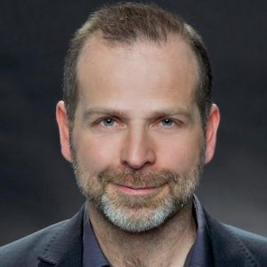

Axel Schumacher

**CH:** Dizileme ve depolama dışında başka hizmetler de sunacak mısınız? Örneğin biyoinformatik analiz gibi.

**AS:** Yakın zamanda bir genetik danışman ağı kurmayı planlıyoruz. Ayrıca sistemimiz üzerinden mobil veya web tabanlı uygulamalar ile son kullanıcılara hizmet vereceğiz. Elbette bir ölçüde biyoinformatik analiz de sağlayabiliriz, ancak bu bizim öncelik verdiğimiz bir konu değil. Bu işlemler muhtemelen partner firmalarımız tarafından gerçekleştirilecektir.

**CH:** Blockchain üzerinde ne tür veriler saklanacak? Küçük boyutlu genom verileri (.vcf gibi) saklanacak mı?

**AS:** Blockchain üzerinde herhangi bir genom verisini saklamayı planlamıyoruz. Verilerin büyük bir kısmı (özellikle dizileme verileri, kişisel bilgiler vs.) firmamızın yerel sunucularında paylaşılacak. Bu sunucularda sadece CRAM, VCF ve BED dosyaları kayıtlı olacak. Blockchain üzerinde saklanacak tek veri, genomunuza ait log kayıtları olacak. Elbette anonim olarak.

**CH:** Whitepaper dokümanınızda, firmanızın kripto parabirimi olan Omix ile müşterilerin dizilemede kullanılabilecek sarf malzemeleri alabilecekleri yazıyor. Bu konu ile ilgili kit üreticileri ile görüştünüz mü? Ödemeleri Omix ile almayı kabul ediyorlar mı?

**AS:** Açıkçası kendi dizileme kitlerimizi üretmeyi planlıyoruz. Yerel ihtiyaçlara göre distribütörler ile de çalışabiliriz. Ancak henüz bir anlaşmamız bulunmuyor. Para birimimiz olan Omix’in kullanılacağı tek yer, oluşturacağımız platform olacak. Bu platform üzerinden kullanıcılar farklı hizmetlerden (sağlık danışma hizmetleri, uygulamalar vs.) yararlanabilecekler. Bu platformu kullanabilecek çok sayıda olası partner ile yaptığımız görüşmelerde, hepsi Omix ile çalışmayı kabul ediyorlar.

Tüm görüşmeden benim anladığım, blockchain teknolojisinin firmada aslında çok küçük bir alanda kullanılacağı oldu. Temelde, blockchain üzerinde **genom verilerinin takibini** sağlayacak bir sistem hedefleniyor. O kadar. Bunun dışındaki hedefler (uygulama oluşturmak, genetik danışmanlığı) çoğu genetik start-up firmasının jenerik fikirlerinden ibaret.

[figure not shown]

# Ve Daha Onlarcası…

Detaylı incelendiğinde benzeri şekilde hizmet veren çok sayıda genetik araştırma firmasının da ortaya çıktığı görülüyor. **EncrypGen**, **Insilico Medicine**, **Zenome** ve **Luna** bunlardan birkaçı. Bunlara her ay yenileri ekleniyor.

Bu firmaların neredeyse tamamı, bireylerin genom verilerinin izne tabi olarak istenilen kurumlarla kolaylıkla paylaşılması üzerine yoğunlaşıyor. Örneğin, bu firmalardan **Nebula Genomics**, tüm genomunuzu 1000$ karşılığında diziledikten sonra sizi genom verilerinizi satabileceğiniz bir gruba bağlıyor. Verileriniz çeşitli kurumlarca (ilaç, biyoteknoloji vs) kullanıldıkça, Nebula firmasının kendine ait kripto para birimleri ile ödeme alıyorsunuz. Eğer kriptoparalar ilginizi çekmiyorsa **DNASimple** veya **Genos** gibi firmalar size dolar üzerinden de ödeme yapabiliyor.

Öte yandan **LunaDNA**, genom verinizi sistemlerine yüklediğinizde kendi kripto para biriminde (LunaCoin) size ödeme yapıyor. **EncrypGen**, benzer bir şekilde çalışıyor ancak genom veriniz yerine, sizden başka metaveriler de (boy, kilo, sağlık durumu vs.) gibi bilgiler de talep ediyor. Yapay zekayı sağlık alanında kullanan Insilico ise oluşturduğu **Longenesis** platformu ile sadece genomunuzu değil, bunun dışındaki tüm sağlık verilerinizi sisteme yükleyip kripto para kazanmanıza olanak veriyor. **Zenome** adı başka bir firma ise genom verinizi yüklediğinizde bunun karşılığında size ZNA token adı verilen kripto para birimi ile ödeme sağlıyor.

Genom verilerinin boyutu yüzünden blockchain üzerinde tutulmasının şimdilik pratik olmadığından bahsetmiştik. Sıkıştırıldığında dahi 3 Gb tutan bir dosyanın 200.000 bilgisayar ile paylaşıldığını düşünmek yeterli. Bu zorluklara rağmen, genom verilerini bu sistem üzerinde saklamayı planlayan firmalar da yok değil. Genecoin adlı firma, sizi siz yapan mutasyonları (vcf dosyası) blockchain üzerinde anonim olarak saklamanızı sağlayacak bir platform geliştirdiğini belirtiyor.

# Blockchain Kullanım Avantajları

Günümüzde, genom dizileme hizmeti sunan klinik ve araştırma laboratuvarlarının büyük bir kısmı, sahip olduğu genom verilerini bir çok kuruma satıyor. **Ne yazık ki, örnek sahiplerinin bu satışı takip edebilme veya engelleme şansı da bulunmuyor.** Bu konu ile ilgili 13.000 kişi üzerinde yapılan bir çalışmada, katılımcıların %86’sının genom verilerinin yanlış amaçla kullanılacağından endişe ettiği belirtilmiş.[^1] Günümüzde bir genom bilgisi 10 dakika içinde bir sunucudan diğerine kopyalanabiliyor. Bunun şirket dışında ne bir kaydı bulunuyor ne de size bir denetim şansı veriliyor.

**Güvenlik ve kontrol zafiyetinin olduğu bu ortamda blockchain önemli bir güvence potansiyeli taşıyor.** Nitekim, blockchain kullanmaya çalışan tüm biyoteknoloji firmaları, genom verilerinin güvenilirliği ve denetimi üzerine hizmet vermeyi hedefliyor. Bu hizmetler kapsamında herhangi bir genom verisine erişildiğinde veya kullanıldığında, bunun kaydı blockchain üzerinde tutuluyor. **Bir veri bir kez kayıt edildikten sonra silinmesi veya değiştirilmesi mümkün olmadığı için**, bir verinin kim tarafından ve ne zaman kullanıldığı takip edilebiliyor.

Her şeyin ötesinde, blockchain kullanımı beraberinde genomik alanda veri güvenliğini de getireceği açık. Bu sayede bireyler kendi genom verilerini takip edebilecek ve daha rahatlıkla paylaşabilecek. Bu durum, **daha fazla sayıda ve çeşitlilikte genom verisinin genetik çalışmalarında kullanılması anlamına geliyor**. Günümüzde, geniş kapsamlı genetik çalışmalarında kullanılan numunelerin %96’sının Avrupa kökenli olması, eldeki verilerin ne ölçüde dengesiz olduğunu gösteriyor. [^2] 2 Bu düşük çeşitlilik, genetik alanında yapılan çalışmaları büyük ölçüde kısıtlıyor. Blockchain’in getireceği güven ortamı, araştırmacıların daha fazla veriye ulaşma şansını arttırabilir.

# Peki Dezavantajlar?

Sağlık ve genomik alanında hizmet veren bu yeni nesil firmaların blockchain sistemleri çok da kusursuz sayılmaz. **Bu firmaların kullandığı kriptoparalar bitcoin gibi geniş ağlar kullanmıyorlar.** Meşhur bitcoin’in avantajı bir merkezi otoritenin olmamasından gelirken, tıbbi bilgi işleyen bu firmaların paraları temelde, ilgili şirketin tekelinde oluyor. Şirket dilediği kadar kripto para basarak veya azaltarak piyasa manipülasyonu yapabiliyor.

Bu durumu bir örnekle açıklamak daha uygun olabilir: Diyelim ki, X firmasından genom dizileme hizmeti aldınız. Firma da genom verilerinizi ilaç firmalarına açmanız karşılığında size **her biri 1 USD değerinde 100 adet X kriptoparası verdi**. Siz de kabul ettiniz. Ancak 1 ay sonra, firma para toplamak için piyasaya daha fazla kriptopara sürdü. **Talep fazlası sebebiyle X kriptoparası 1 USD’den 0.5 USD’ye** indi. **1 ay önceki genom veriniz bir anda %50 değer kaybetti bile**. Tamamen firmanın verdiği kararlar ile. **Ne bir regülasyon ne de bir kontrol**.

Bir diğer problem, bu firmaların hepsinin kendi para birimini kullanması. **EncrypGen** adlı firmadan kazandığınız kriptoparaları **LunaDNA**‘da veya **Zenome** firmalarında kullanma şansınız yok. Sağlık verilerinin sağlık kuruluşları arasında transfer edilmesinde bu tür çok başlılıkların çıkaracağı zorlukları kestirmek güç değil.

Her şeyden öte, şu anda **genom analiz hizmetini sağlayan kuruluşlar ile blockchain üzerinden genetik veri güvenliği sağlayan kuruluşlar birbirinden farklı**. Laboratuvarlar genom verilerini, bu start-up’lara gönderiyor ve onlar da bunu şifreliyorlar. Bundan sonraki tüm süreç, kayıtlar halinde blockchain üzerinde tutuluyor. **Peki öncesi?** Çalışmayı gerçekleştiren laboratuvarlarda veya taşıma süresince genom verilerinizin kopyalanamaz mı? Bunun cevabı ne yazık ki evet. Verilerinizin bu süreçte kopyalanıp başka bir yere taşınmasını blockchain ile takip etme şansınız yok. **Çünkü, gönderdiğiniz numune üzerinden genom verileriniz çıkarılana kadar laboratuvarda onlarca basamak gerçekleştiriliyor**. Veriler bir kez çıktıktan sonra, bunların biyoinformatik analizi sırasında da bir o kadar işlem gerçekleştiriliyor. Bu basamaklar süresince verilerinizin kötü niyetli kurum/kişiler tarafından kopyalanmasının önüne geçmeniz veya blockchain ile takip etmeniz mümkün değil.

# Son Söz

Blockchain oldukça yeni bir teknoloji. Ancak çoğu firma bu sistemi getirdiği yenilikler yüzünden değil, “**popüler**” olmasından dolayı kullanıyorlar. Şu anki durumda, genetik alanındaki kullanım alanları oldukça kısıtlı. Start-up firmalar, yüzlerce diğer firma arasından kendilerini sıyırmak için bu tür “**tekno-havalı**” kelimeleri kullanıyorlar. Genomik verilerin chain üzerinde tutulmasının teorik zorlukları bir yana, ne tür bir faydasının olacağı da şüpheli. Veri güvenliği sağlayan firmalarda ise, veri üretiminden depolamaya gidene kadar geçen adımlar, hala ciddi bir güvenlik açığı. Ve blockchain’in buna karşılık sunacağı bir çözüm yok.

Ancak, blockchain oldukça yeni bir teknoloji. Ve uygulama alanlarını incelerken çok acımasız olmamak gerek. Zamanla, genetik alanında daha doğru kullanım yollarının bulunacağına ve varolan yollardaki sorunlara çözüm bulunacağına eminim.

[^1]: Sanderson S, Brothers K, Mercaldo N, et al. Public Attitudes toward Consent and Data Sharing in Biobank Research: A Large Multi-site Experimental Survey in the US. Am J Hum Genet. 2017;100(3):414-427.
[^2]: Need A, Goldstein D. Next generation disparities in human genomics: concerns and remedies. Trends Genet. 2009;25(11):489-494

**Can Holyavkin**

E-posta | [Linkedin](https://www.linkedin.com/in/can-holyavkin/) | [Twitter](https://twitter.com/CanHolyavkin)